# Mulitvariable Regression

Institut für Organisation und Globale Managementstudien, JKU Linz

## Muitivariable Regression Analysis

## Motivating Example 1

- If I were to present evidence of a **relationship between breath mint useage** (mints per day, X) **and pulmonary function** (measured in FEV, Y), you would be skeptical.
- Likely, you would say, "smokers tend to use more breath mints than non smokers, smoking is related to a loss in pulmonary function. That's probably the culprit."
- If asked what would convince you, you would likely say, "If non-smoking breath mint users had lower lung function than non-smoking non-breath mint users and, similarly, if smoking breath mint users had lower lung function than smoking non-breath mint users, I'd be more inclined to believe you".
- In other words, to even consider my results, I would have to demonstrate that they hold while holding smoking status fixed.

## Motivating Example 2

- A health insurance company is interested in how last year's claims can **predict a person's time in the hospital this year**.
- They want to use an enormous amount of data contained in claims to predict a single number. Simple linear regression is not equipped to handle more than one predictor.
- How can one generalize SLR to incoporate lots of regressors for the purpose of prediction?
- What are the consequences of adding lots of regressors?
  - Surely there must be consequences to throwing variables in that  
    aren't related to Y?
  - Surely there must be consequences to omitting variables that are?

## The Linear Model

- The general linear model extends simple linear regression (SLR) by adding terms linearly into the model. \[ Y_i = \beta_1 X_{1i} + \beta_2 X_{2i} + \ldots + \beta_{p} X_{pi} + \epsilon_{i} = \sum_{k=1}^p X_{ik} \beta_j + \epsilon_{i} \]
  - Here \(X_{1i}=1\) typically, so that an intercept is included.
- Sidenote: The important linearity is linearity in the coefficients. Thus \[ Y_i = \beta_1 X_{1i}^2 + \beta_2 X_{2i}^2 + \ldots + \beta_{p} X_{pi}^2 + \epsilon_{i} \] is still a linear model. (We've just squared the elements of the predictor variables.)

## Swiss Fertility Data

## `?swiss`

Standardized fertility measure and socio-economic indicators for each of 47 French-speaking provinces of Switzerland at about 1888.

A data frame with 47 observations on 6 variables, each of which is in percent, i.e., in [0, 100].

- [,1] Fertility Ig, ‘common standardized fertility measure’
- [,2] Agriculture % of males involved in agriculture as occupation
- [,3] Examination % draftees receiving highest mark on army examination
- [,4] Education % education beyond primary school for draftees.
- [,5] Catholic % ‘catholic’ (as opposed to ‘protestant’).
- [,6] Infant.Mortality live births who live less than 1 year.

All variables but ‘Fertility’ give proportions of the population.

## Fertility and Agriculture

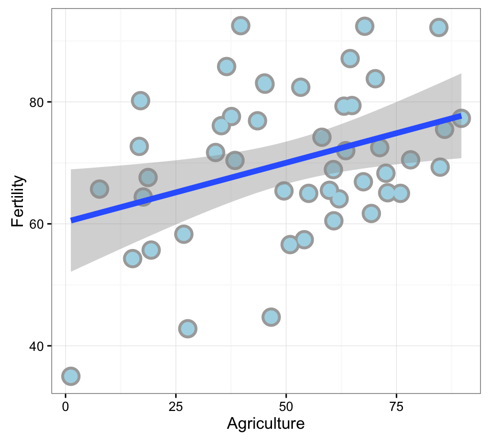

## LMa: Fertility ~ Agriculture

```r
lma <- lm(Fertility ~ Agriculture, swiss)
summary(lma)
```

```
##
## Call:
## lm(formula = Fertility ~ Agriculture, data = swiss)
##
## Residuals:
##      Min       1Q   Median       3Q      Max
## -25.5374  -7.8685  -0.6362   9.0464  24.4858
##
## Coefficients:
##             Estimate Std. Error t value Pr(>|t|)
## (Intercept) 60.30438    4.25126  14.185   <2e-16 ***
## Agriculture  0.19420    0.07671   2.532   0.0149 *
## ---
## Signif. codes:  0 '***' 0.001 '**' 0.01 '*' 0.05 '.' 0.1 ' ' 1
##
## Residual standard error: 11.82 on 45 degrees of freedom
## Multiple R-squared:  0.1247, Adjusted R-squared:  0.1052
## F-statistic: 6.409 on 1 and 45 DF,  p-value: 0.01492
```

## LMa: Interpretation

- We estimate an expected 0.19 \(\pm\) 0.15 increase in standardized fertility for every 1% increase in percentage of males involved in agriculture.
- The t-test for \(H_0: \beta_{Agri} = 0\) versus \(H_a: \beta_{Agri} \neq 0\) is significant.
- This model explains 12.47% of variability in fertility rates.

## LMb: "Complete" Model

```r
lmb <- lm(Fertility ~ ., swiss)
summary(lmb)
```

```
##
## Call:
## lm(formula = Fertility ~ ., data = swiss)
##
## Residuals:
##      Min       1Q   Median       3Q      Max
## -15.2743  -5.2617   0.5032   4.1198  15.3213
##
## Coefficients:
##                  Estimate Std. Error t value Pr(>|t|)
## (Intercept)      66.91518   10.70604   6.250 1.91e-07 ***
## Agriculture      -0.17211    0.07030  -2.448  0.01873 *
## Examination      -0.25801    0.25388  -1.016  0.31546
## Education        -0.87094    0.18303  -4.758 2.43e-05 ***
## Catholic          0.10412    0.03526   2.953  0.00519 **
## Infant.Mortality  1.07705    0.38172   2.822  0.00734 **
## ---
## Signif. codes:  0 '***' 0.001 '**' 0.01 '*' 0.05 '.' 0.1 ' ' 1
##
## Residual standard error: 7.165 on 41 degrees of freedom
## Multiple R-squared:  0.7067, Adjusted R-squared:  0.671
## F-statistic: 19.76 on 5 and 41 DF,  p-value: 5.594e-10
```

## LMb: Interpretation

- We estimate an expected 0.17 \(\pm\) 0.14 **decrease (!)** in standardized fertility for every 1% increase in percentage of males involved in agriculture in **holding the remaining variables constant**.
- The t-test for \(H_0: \beta_{Agri} = 0\) versus \(H_a: \beta_{Agri} \neq 0\) is significant.
- This ("complete") model explains 70.67% of variability in fertility rates.

## Quick Pair Plots

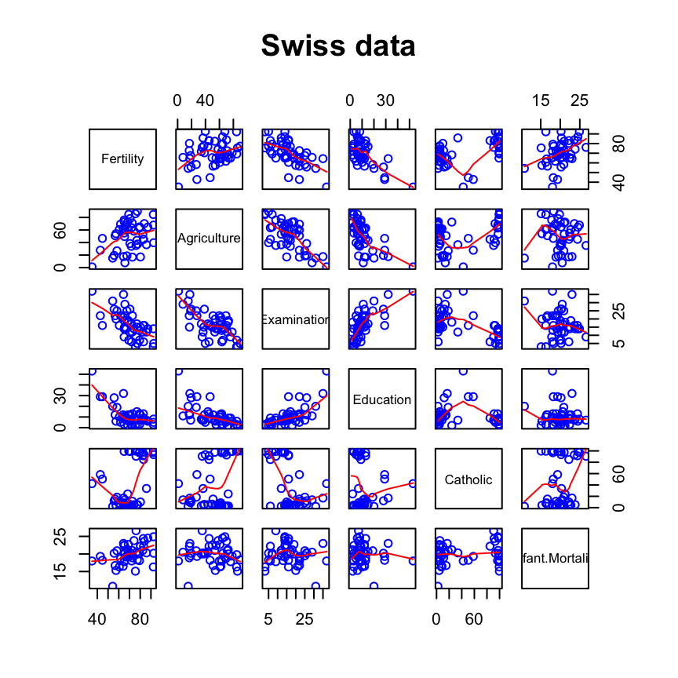

```r
pairs(swiss, panel = panel.smooth, main = "Swiss data", col = 4)
```

## LMb: Interpretation (cont'd)

- The sign reverses itself with the inclusion of Examination and Education, which are negatively correlated with Agriculture.
- The percent of males in the province working in agriculture is negatively related to educational attainment (correlation of -0.64) and Education and Examination (correlation of 0.7) are obviously measuring similar things.
- At the minimum, anyone claiming that provinces that are more agricultural have higher fertility rates would immediately be open to criticism.

How can adjustment reverse the sign of an effect? Let's try a simulation.

```r
n <- 100; x2 <- 1 : n; x1 <- .01 * x2 + runif(n, -.1, .1); y = -x1 + x2 + rnorm(n, sd = .01)
summary(lm(y ~ x1))$coef
```

```
##              Estimate Std. Error   t value     Pr(>|t|)
## (Intercept)  1.717037   1.186564  1.447066 1.510697e-01
## x1          93.821994   1.995617 47.014028 4.819826e-69
```

```r
summary(lm(y ~ x1 + x2))$coef
```

```
##                  Estimate   Std. Error      t value      Pr(>|t|)
## (Intercept) -0.0004419003 0.0022242917   -0.1986701  8.429366e-01
## x1          -1.0141158853 0.0181506747  -55.8720765  1.412345e-75
## x2           1.0001981487 0.0001874049 5337.0978326 5.214253e-267
```

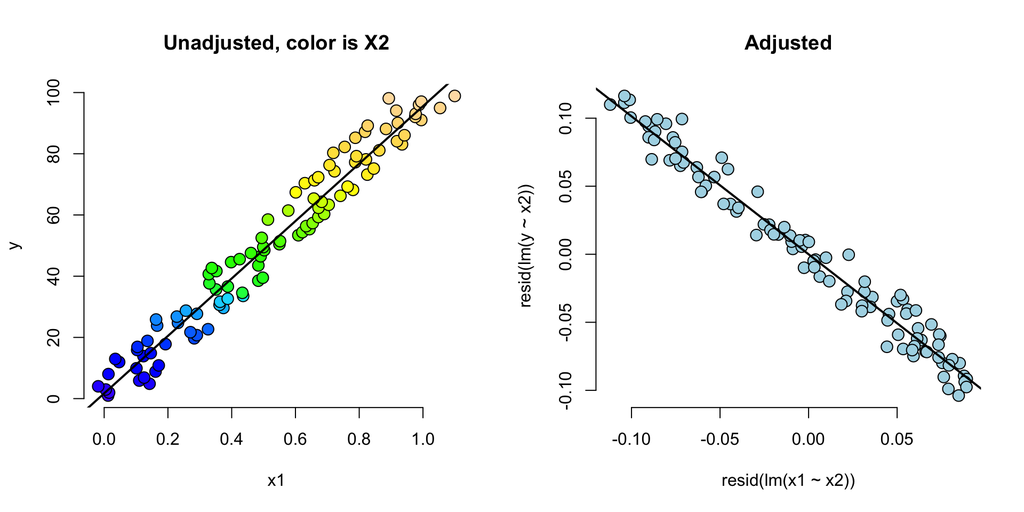

## Factor Variable as Predictors

## Dataset `mtcars`

```r
aggregate(mpg ~ am, mtcars, mean)
```

```
##   am      mpg
## 1  0 17.14737
## 2  1 24.39231
```

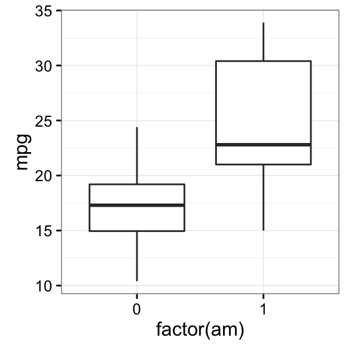

```r
ggplot(mtcars, aes(factor(am), mpg)) + geom_boxplot() + theme_bw()
```

## Regression Model

```r
fit <- lm(mpg ~ am, mtcars)
summary(fit)
```

```
##
## Call:
## lm(formula = mpg ~ am, data = mtcars)
##
## Residuals:
##     Min      1Q  Median      3Q     Max
## -9.3923 -3.0923 -0.2974  3.2439  9.5077
##
## Coefficients:
##             Estimate Std. Error t value Pr(>|t|)
## (Intercept)   17.147      1.125  15.247 1.13e-15 ***
## am             7.245      1.764   4.106 0.000285 ***
## ---
## Signif. codes:  0 '***' 0.001 '**' 0.01 '*' 0.05 '.' 0.1 ' ' 1
##
## Residual standard error: 4.902 on 30 degrees of freedom
## Multiple R-squared:  0.3598, Adjusted R-squared:  0.3385
## F-statistic: 16.86 on 1 and 30 DF,  p-value: 0.000285
```

## Dummy Variables are Smart

- Consider the linear model \[ Y_i = \beta_0 + X_{i1} \beta_1 + \epsilon_{i} \] where each \(X_{i1}\) is binary. (cars with manual transmission \(X_1 = 1\), cars with automatic transmission \(X_1 = 0\))
- Then for cars in the group (manual) \(E[Y_i] = \beta_0 + \beta_1\)
- And for cars not in the group (automatic) \(E[Y_i] = \beta_0\)
- The LS fits work out to be \(\hat \beta_0 + \hat \beta_1\) is the mean for those in the group and \(\hat \beta_0\) is the mean for those not in the group.
- \(\beta_1\) is interpreted as the increase or decrease in the mean comparing those in the group to those not.

## More than 2 levels

- Consider a multilevel factor level. For didactic reasons, let's say a three level factor (example, US political party affiliation: Republican, Democrat, Independent)
- \(Y_i = \beta_0 + X_{i1} \beta_1 + X_{i2} \beta_2 + \epsilon_i\).
- \(X_{i1}\) is 1 for Republicans and 0 otherwise.
- \(X_{i2}\) is 1 for Democrats and 0 otherwise.
- If \(i\) is Republican \(E[Y_i] = \beta_0 +\beta_1\)
- If \(i\) is Democrat \(E[Y_i] = \beta_0 + \beta_2\).
- If \(i\) is Independent \(E[Y_i] = \beta_0\).
- \(\beta_1\) compares Republicans to Independents.
- \(\beta_2\) compares Democrats to Independents.
- \(\beta_1 - \beta_2\) compares Republicans to Democrats.
- (Choice of reference category changes the interpretation.)

## Insect Sprays

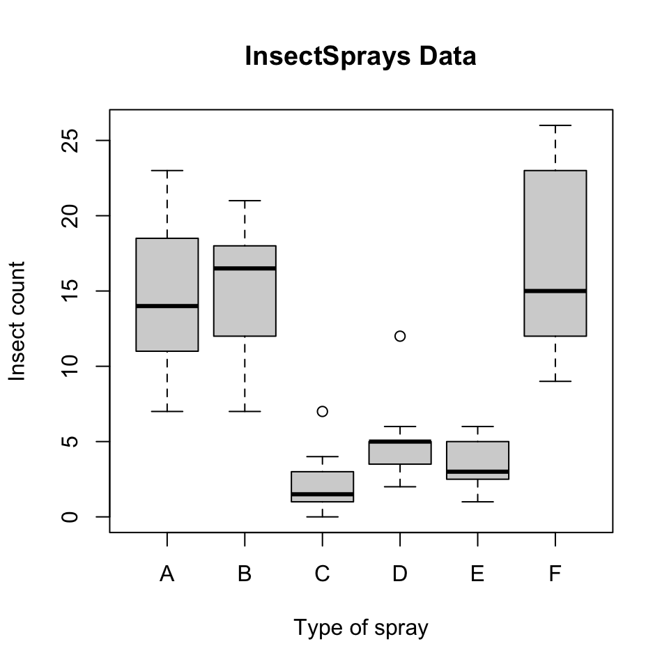

## Linear model fit, group A is the reference

```r
summary(lm(count ~ spray, data = InsectSprays))$coef
```

```
##                Estimate Std. Error    t value     Pr(>|t|)
## (Intercept)  14.5000000   1.132156 12.8074279 1.470512e-19
## sprayB        0.8333333   1.601110  0.5204724 6.044761e-01
## sprayC      -12.4166667   1.601110 -7.7550382 7.266893e-11
## sprayD       -9.5833333   1.601110 -5.9854322 9.816910e-08
## sprayE      -11.0000000   1.601110 -6.8702352 2.753922e-09
## sprayF        2.1666667   1.601110  1.3532281 1.805998e-01
```

## Hard coding the dummy variables

```r
summary(lm(count ~
             I(1 * (spray == 'B')) + I(1 * (spray == 'C')) +
             I(1 * (spray == 'D')) + I(1 * (spray == 'E')) +
             I(1 * (spray == 'F'))
           , data = InsectSprays))$coef
```

```
##                          Estimate Std. Error    t value     Pr(>|t|)
## (Intercept)            14.5000000   1.132156 12.8074279 1.470512e-19
## I(1 * (spray == "B"))   0.8333333   1.601110  0.5204724 6.044761e-01
## I(1 * (spray == "C")) -12.4166667   1.601110 -7.7550382 7.266893e-11
## I(1 * (spray == "D"))  -9.5833333   1.601110 -5.9854322 9.816910e-08
## I(1 * (spray == "E")) -11.0000000   1.601110 -6.8702352 2.753922e-09
## I(1 * (spray == "F"))   2.1666667   1.601110  1.3532281 1.805998e-01
```

## Summary

- If we treat Spray as a factor, R includes an intercept and omits the alphabetically first level of the factor.
- All t-tests are for comparisons of Sprays versus Spray A.
- Empirical mean for A is the intercept.
- Other group means are the intercept plus their coefficient.
- If we omit an intercept, then it includes terms for all levels of the factor.
- Group means are the coefficients.
- Tests are tests of whether the groups are different than zero. (Are the expected counts zero for that spray.)
- If we want comparisons between, Spray B and C, say we could refit the model with C (or B) as the reference level.

## Reordering the levels

```r
spray2 <- relevel(InsectSprays$spray, "C")
summary(lm(count ~ spray2, data = InsectSprays))$coef
```

```
##              Estimate Std. Error  t value     Pr(>|t|)
## (Intercept)  2.083333   1.132156 1.840148 7.024334e-02
## spray2A     12.416667   1.601110 7.755038 7.266893e-11
## spray2B     13.250000   1.601110 8.275511 8.509776e-12
## spray2D      2.833333   1.601110 1.769606 8.141205e-02
## spray2E      1.416667   1.601110 0.884803 3.794750e-01
## spray2F     14.583333   1.601110 9.108266 2.794343e-13
```

## Acknowledgements

This class and many slides were inspired by:

**Brian Caffo, Jeff Leek, and Roger Peng**  
Department of Biostatistics  
Johns Hopkins Bloomberg School of Public Health

and the

[Coursera Data Science Specialization Program](https://www.coursera.org/specialization/jhudatascience/1?utm_medium=courseDescripTop)